# Physical-health quality of life in Brazilian medical students

Dataset 7: Resilience, learning environment and quality of life in Brazilian medical students

RSR feasibility analysis

2026-08-03

# Introduction

Tempski and colleagues surveyed a random sample of 1,350 students at 22 Brazilian medical schools in 2011-2012, measuring quality of life (WHOQOL-BREF), the perceived educational environment (DREEM), resilience, depressive symptoms and anxiety in a single cross-sectional questionnaire (Tempski et al., *PLOS ONE* 2015; doi:10.1371/journal.pone.0131535). The physical domain of the WHOQOL-BREF covers sleep, energy, pain, mobility, everyday activity capacity and dependence on medication - the concrete daily costs of medical training, and the domain most likely to respond to changes in workload and rota design.

**Aim.** Among Brazilian medical students, we examined which of sex, age, stage of the course, school legal status, resilience, the perceived educational environment and depressive symptoms are independently associated with physical-health quality of life, mutually adjusting for the others.

This is a *Purpose 3* analysis: several predictors are of interest and the question is which remain associated with the outcome after mutual adjustment.

# Methods

**Data source.** Multicentre cross-sectional survey of a random sample of 1,350 students drawn from 22 medical schools across Brazil, stratified by stage of the course (basic sciences, clinical sciences, clerkship). All variables used here are complete.

**Variables.** The outcome is `whoqol_physical`, the WHOQOL-BREF physical health domain transformed to a 0-100 scale where higher is better. Predictors are sex (reference: female, the larger group), age in years, stage of the course (reference: basic sciences, the earliest stage), school legal status (reference: public, the larger group and the traditional Brazilian medical school), the resilience scale score (16-98, higher = more resilient), the DREEM global score (sum of the five DREEM subscales, higher = a more positive perceived educational environment), and the Beck Depression Inventory total (0-63, higher = more depressive symptoms). All continuous predictors are modelled per one-unit increase.

Three deliberate choices about construct overlap. First, `dreem_global` is used **instead of** the five DREEM subscales, because the global score is their exact arithmetic sum and the two sets cannot appear in one model. Second, no other WHOQOL domain is used as a predictor: physical, psychological, social and environment are subscales of one instrument, and regressing one on another describes the questionnaire rather than the students. Third, of the three negative-affect scales (`bdi_depression`, `state_anxiety`, `trait_anxiety`) only the BDI is included. The three correlate at *r* = 0.59 to 0.73 with each other; including all three would split one construct across three collinear terms and make each coefficient uninterpretable. The BDI was chosen because somatic items (sleep, appetite, fatigue) give it the clearest substantive link to physical quality of life - a link that is also its weakness, discussed below.

**Statistical analysis.** Linear regression (`lm()`), justified because the outcome is continuous and roughly symmetric. We fitted a univariable model for each predictor first, then a single multivariable model containing all of them. Predictors were chosen in advance on subject-matter grounds, not by significance. Significance threshold 0.05; estimates are reported with 95% confidence intervals. Assumptions were checked with `performance::check_model()`. Analysis used R version 4.6.0 (2026-04-24) with tidyverse, gtsummary and performance.

**Missing data.** Complete-case analysis: 1350 of 1350 rows were analysed (0 dropped).

# Results

## Sample characteristics

**Table 1. Sample characteristics.**

| **Characteristic** | **N** | **N = 1,350**<sup>1</sup> |
| --- | --- | --- |
| WHOQOL physical domain (0-100) | 1,350 | 68 (54, 75) |
| Sex | 1,350 |  |
| Female |  | 714 (53%) |
| Male |  | 636 (47%) |
| Age (years) | 1,350 | 22.00 (21.00, 24.00) |
| Stage of course | 1,350 |  |
| Basic sciences |  | 459 (34%) |
| Clinical sciences |  | 491 (36%) |
| Clerkship |  | 400 (30%) |
| School legal status | 1,350 |  |
| Public |  | 882 (65%) |
| Private |  | 468 (35%) |
| Resilience score (16-98) | 1,350 | 81 (73, 88) |
| DREEM global score (0-200) | 1,350 | 120 (101, 139) |
| BDI depressive symptoms (0-63) | 1,350 | 8 (4, 13) |

<sup>1</sup> Median (Q1, Q3); n (%)

The median physical-domain score was 67.9 out of 100, higher than the psychological domain in the same students. Two thirds attended public schools, students were evenly spread across the three stages of the course, and the median BDI score of 8 sits below the conventional threshold of 14 for moderate depression - though the upper range reaches 42.

## Exploratory figure

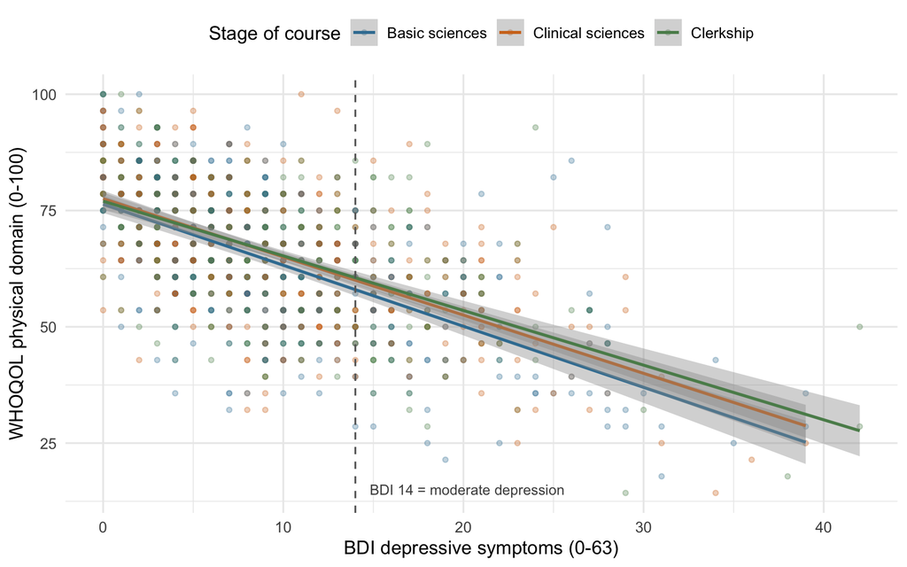

Figure 1. Physical-health quality of life against depressive symptoms, by stage of the course. Points are individual students; lines are linear smoothers.

Physical quality of life declines steadily and near-linearly with depressive symptoms across the whole BDI range, and the clerkship line sits slightly above the basic-sciences line at every level of depression, hinting that the later stages of the course are not the worst for physical wellbeing.

## Univariable models

**Univariable linear regression.**

| **Characteristic** | **Beta** | **95% CI** | **p-value** |
| --- | --- | --- | --- |
| Sex |  |  |  |
| Female | — | — |  |
| Male | 4.0 | 2.4, 5.5 | <0.001 |
| Age (years) | 0.22 | -0.04, 0.49 | 0.093 |
| Stage of course |  |  |  |
| Basic sciences | — | — |  |
| Clinical sciences | 2.2 | 0.29, 4.0 | 0.024 |
| Clerkship | 2.6 | 0.65, 4.6 | 0.009 |
| School legal status |  |  |  |
| Public | — | — |  |
| Private | 1.7 | 0.01, 3.3 | 0.048 |
| Resilience score (16-98) | 0.52 | 0.46, 0.57 | <0.001 |
| DREEM global score (0-200) | 0.23 | 0.20, 0.26 | <0.001 |
| BDI depressive symptoms (0-63) | -1.3 | -1.3, -1.2 | <0.001 |

Abbreviation: CI = Confidence Interval

Depressive symptoms are the strongest crude predictor: each additional BDI point is associated with a 1.26-point *lower* physical-domain score (95% CI -1.35 to -1.17, p < 0.001), so a student at the moderate-depression threshold of 14 scores about 18 points lower than one scoring 0. Resilience (0.52 points per point, 95% CI 0.46 to 0.57) and the DREEM global score (0.23 per point) are both positively associated. Men score 3.95 points higher than women crudely, clerkship students 2.61 points higher than basic-sciences students, and private-school students 1.66 points higher than public-school students. Age shows no crude association (p = 0.09).

## Why adjustment is needed

The crude estimates are confounded by variables that sit upstream of both the predictor and the outcome. **Depressive symptoms** confound the resilience association: students with high BDI scores score much lower on the resilience scale (*r* = -0.57) and also report worse physical quality of life, so a large part of the crude resilience coefficient is depression rather than resilience. **Depressive symptoms** also confound the DREEM association in the same direction - a depressed student rates the learning environment more harshly (*r* = -0.41) and reports worse physical wellbeing - so the crude environment effect is partly the mood of the rater. **Stage of the course** confounds the crude age association: clerkship students are older by construction, and the stages differ in workload and clinical exposure, so without adjustment an age coefficient is really a mixture of ageing and progression. **School legal status** is a fourth: private-school students in Brazil come from wealthier families, and family wealth plausibly affects both the ability to afford a private place and the sleep, nutrition and health care that the physical domain measures. Fitting all seven predictors together lets each be read holding the others fixed.

## Multivariable model

**Multivariable linear regression.**

| **Characteristic** | **Beta** | **95% CI** | **p-value** |
| --- | --- | --- | --- |
| Sex |  |  |  |
| Female | — | — |  |
| Male | 1.4 | 0.21, 2.7 | 0.022 |
| Age (years) | 0.02 | -0.22, 0.25 | 0.9 |
| Stage of course |  |  |  |
| Basic sciences | — | — |  |
| Clinical sciences | 2.2 | 0.71, 3.7 | 0.004 |
| Clerkship | 3.0 | 1.2, 4.8 | <0.001 |
| School legal status |  |  |  |
| Public | — | — |  |
| Private | -0.31 | -1.6, 1.0 | 0.6 |
| Resilience score (16-98) | 0.09 | 0.02, 0.15 | 0.008 |
| DREEM global score (0-200) | 0.11 | 0.09, 0.14 | <0.001 |
| BDI depressive symptoms (0-63) | -0.97 | -1.1, -0.86 | <0.001 |

Abbreviation: CI = Confidence Interval

**Model fit**

| Statistic | Value |
| --- | --- |
| R-squared | 0.410 |
| Adjusted R-squared | 0.407 |
| Residual SE | 11.32 |
| n | 1350 |
| Model df | 8 |

The model explains 41.0% of the variance in physical quality of life (adjusted R-squared 0.407). Holding the other six predictors fixed, each BDI point is associated with a -0.97 (95% CI -1.08 to -0.86)-point change in the physical domain - still by far the largest contribution. The DREEM global score keeps an independent association of 0.11 (95% CI 0.09 to 0.14) points per point, about 2.3 points across a 20-point difference in perceived environment. Resilience retains a small independent association (0.09 (95% CI 0.02 to 0.15) points per point). Men score 1.44 (95% CI 0.21 to 2.67) points higher than women. Notably, the stage of the course strengthens after adjustment: clerkship students score 3.02 (95% CI 1.23 to 4.81) points higher and clinical-sciences students 2.23 (95% CI 0.71 to 3.74) points higher than basic-sciences students, conditional on depression and everything else. Age (0.02 (95% CI -0.22 to 0.25)) and private schooling (-0.31 (95% CI -1.63 to 1.00)) show no independent association. All of these are conditional associations in a single-timepoint survey, not effects of intervention.

## Unadjusted versus adjusted

**Table 2. Unadjusted and adjusted estimates.**

| **Characteristic** | **Unadjusted** **Beta** | **Unadjusted** **95% CI** | **Unadjusted** **p-value** | **Adjusted** **Beta** | **Adjusted** **95% CI** | **Adjusted** **p-value** |
| --- | --- | --- | --- | --- | --- | --- |
| Sex |  |  |  |  |  |  |
| Female | — | — |  | — | — |  |
| Male | 4.0 | 2.4, 5.5 | <0.001 | 1.4 | 0.21, 2.7 | 0.022 |
| Age (years) | 0.22 | -0.04, 0.49 | 0.093 | 0.02 | -0.22, 0.25 | 0.9 |
| Stage of course |  |  |  |  |  |  |
| Basic sciences | — | — |  | — | — |  |
| Clinical sciences | 2.2 | 0.29, 4.0 | 0.024 | 2.2 | 0.71, 3.7 | 0.004 |
| Clerkship | 2.6 | 0.65, 4.6 | 0.009 | 3.0 | 1.2, 4.8 | <0.001 |
| School legal status |  |  |  |  |  |  |
| Public | — | — |  | — | — |  |
| Private | 1.7 | 0.01, 3.3 | 0.048 | -0.31 | -1.6, 1.0 | 0.6 |
| Resilience score (16-98) | 0.52 | 0.46, 0.57 | <0.001 | 0.09 | 0.02, 0.15 | 0.008 |
| DREEM global score (0-200) | 0.23 | 0.20, 0.26 | <0.001 | 0.11 | 0.09, 0.14 | <0.001 |
| BDI depressive symptoms (0-63) | -1.3 | -1.3, -1.2 | <0.001 | -0.97 | -1.1, -0.86 | <0.001 |

Abbreviation: CI = Confidence Interval

**Resilience** moves the furthest toward the null, from 0.52 crude to 0.09 adjusted - only 17% of its crude size survives. Almost all of the crude resilience association was depression: highly resilient students are mostly students with low BDI scores. **The DREEM global score** halves, from 0.23 to 0.11 (50% retained), for the same reason. By contrast **depressive symptoms** barely move, from -1.26 to -0.97 (77% retained) - none of the other six predictors explains away the BDI association.

## Diagnostics

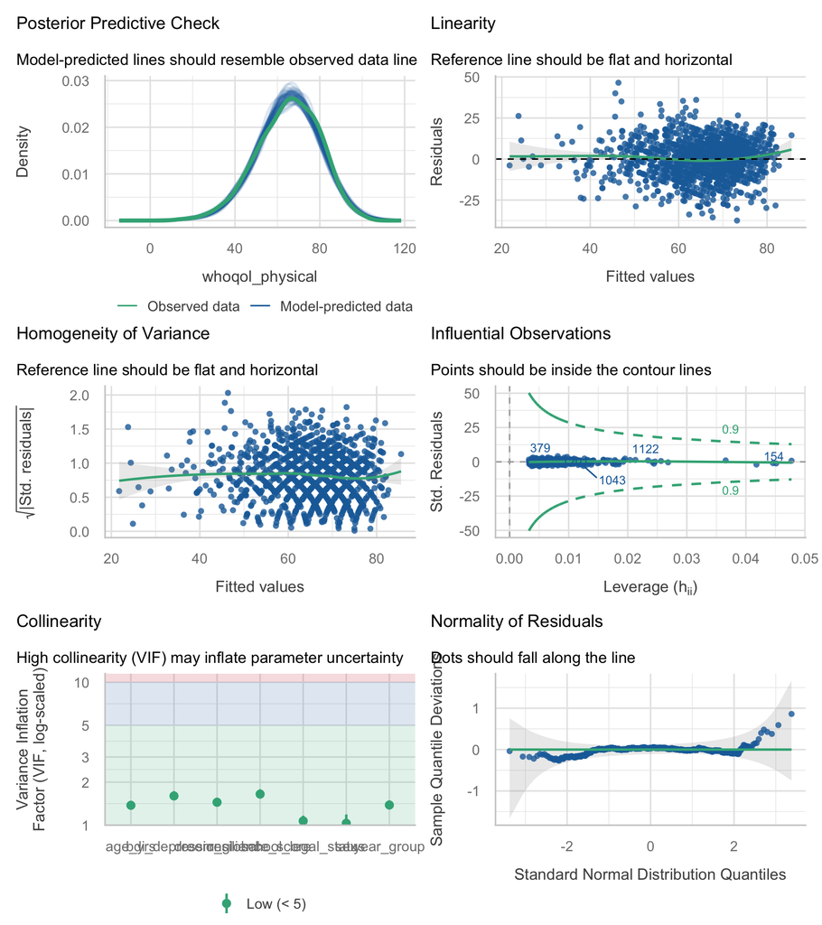

**Variance inflation factors**

| Term | VIF | Tolerance |
| --- | --- | --- |
| sex | 1.03 | 0.970 |
| age_yrs | 1.38 | 0.726 |
| year_group | 1.38 | 0.723 |
| school_legal_status | 1.07 | 0.934 |
| resilience_score | 1.65 | 0.606 |
| dreem_global | 1.45 | 0.691 |
| bdi_depression | 1.60 | 0.624 |

**HC3 robust standard errors (sensitivity check)**

| term | estimate | robust SE | statistic | p.value |
| --- | --- | --- | --- | --- |
| (Intercept) | 51.316 | 4.147 | 12.37 | < 0.001 |
| sexMale | 1.441 | 0.633 | 2.28 | 0.02293 |
| age_yrs | 0.016 | 0.133 | 0.12 | 0.90248 |
| year_groupClinical sciences | 2.228 | 0.784 | 2.84 | 0.00458 |
| year_groupClerkship | 3.020 | 0.961 | 3.14 | 0.00170 |
| school_legal_statusPrivate | -0.311 | 0.668 | -0.47 | 0.64144 |
| resilience_score | 0.085 | 0.033 | 2.62 | 0.00898 |
| dreem_global | 0.114 | 0.015 | 7.85 | < 0.001 |
| bdi_depression | -0.967 | 0.061 | -15.79 | < 0.001 |

Every conclusion is unchanged under HC3; the robust standard errors differ from the model-based ones by only a few percent, so the heteroscedasticity is a bounded-scale artefact rather than a threat to inference.

**Influential points.** No observation exceeds the Cook’s distance threshold; the largest Cook’s distance is 0.019, far below 0.5.

**Collinearity.** The highest VIF is 1.65, all values are below 2, and no term is near the conventional threshold of 5. This is the payoff for using one negative-affect scale rather than three: had `state_anxiety` and `trait_anxiety` been added alongside the BDI, the VIFs for the three would have risen sharply and the split of the joint effect between them would have been arbitrary.

# Discussion

Among Brazilian medical students, physical-health quality of life is most strongly and independently associated with depressive symptoms; a student at the moderate-depression threshold scores roughly 14 points lower on the 0-100 physical domain than a student with no depressive symptoms, holding sex, age, stage, school type, resilience and the perceived environment fixed. The perceived educational environment retains a genuine independent association of about 2.3 points per 20 DREEM points, which is the most actionable finding here because DREEM scores are a school-level target in a way that a student’s depression is not. Resilience, once depression is accounted for, adds little.

**Limitations.** *Construct overlap between the BDI and the outcome.* The BDI contains somatic items on sleep, fatigue, appetite and loss of libido, and the WHOQOL physical domain asks about sleep, energy and everyday capacity; part of the large BDI coefficient is the two instruments asking the same questions. The overlap is smaller than for the psychological domain but it is real, and the coefficient should not be read as “treating depression would raise physical quality of life by this much”. *Clustering is not modelled.* Students came from 22 medical schools, but the released file carries no school identifier - only `school_legal_status` and `school_location` - so the shared teachers, curriculum, rota and city of each school cannot be represented. Standard errors are therefore too narrow, and the school-type coefficient is a crude two-category stand-in for between-school variation that would have been better handled with a random intercept. *Cross-sectional design.* Everything was measured at one sitting; poor physical health causing depression is as plausible as the reverse. *Common-method bias.* All psychosocial measures are self-reported on the same questionnaire, so a globally negative respondent inflates every association at once. *No objective measures* of sleep, exercise, workload or hours on duty are available, so the mechanism behind the clerkship advantage cannot be examined.

**Future work.** Link the questionnaire to objective rota and sleep data and retain the school identifier, so that between-school differences in workload can be separated from between-student differences in mood.

# Feasibility notes

*Not part of a student report.*